# xwMOOC 자연어 처리 - 텍스트

네이버 뉴스 - RmecabKo (형태소 분석)

# 1 네이버 뉴스 [^1]

```r
# 0. 환경설정 -----
library(tidyverse)
library(rvest)
library(glue)

# 1. 데이터 긁어오기 -----
## 네이버 뉴스 함수 작성
get_naver_news <- function(keyword, page){

  url <- glue("https://search.naver.com/search.naver?&where=news&query=",keyword,"&sm=tab_pge&sort=0&photo=0&field=0&reporter_article=&pd=1&ds=2018.02.25&de=2018.03.04&docid=&nso=so:r,p:1w,a:all&mynews=0&cluster_rank=38&start=", page,"&refresh_start=0")

  news_html <- read_html(url, handle = curl::new_handle("useragent" = "Mozilla/5.0"))
  title     <- html_nodes(news_html, xpath='//*[@class="type01"]/li/dl/dt/a') %>% html_text
  source   <- html_nodes(news_html, xpath='//*[@class="type01"]/li/dl/dd[1]/span[1]') %>% html_text
  text  <- html_nodes(news_html, xpath='//*[@class="type01"]/li/dl/dd[2]') %>%  html_text

  news_df <- data.frame(title, source, text)
  return(news_df)
}

page_list <- 1:10
keyword_list <- rep("빅데이터", 10)

ds_df <- map2_df(keyword_list, page_list, get_naver_news)

DT::datatable(ds_df)
```

|  | title | source | text |
| --- | --- | --- | --- |
| 1 | 화성시, ‘스마트시티 빅데이터 분석 플랫폼’ 시범 운영 | CNB뉴스 | ▲ CNB뉴스, CNBNEWS, 씨앤비뉴스 화성시가 데이터 기반의 시민 중심 서비스 제공을 위해 ‘스마트시티 빅데이터 분석 플랫폼’을 구축하고 9월말 시범운영에 나선다. 사업은 정부의 스마트시티 육성 전략에 발맞춰 LH가... |
| 2 | 개그맨 브랜드평판 빅데이터 분석결과...1위 유재석, 2위 박나래 | 위키트리 | 빅데이터 분석 결과, 1위 유재석 2위 박나래 3위 이영자 로 분석되었다. 한국기업평판연구소는 2018년 8월 23일부터 2018년 9월 24일까지 대한민국 소비자들에게 사랑받는 100명의 개그맨 브랜드 빅데이터 139,168... |
| 3 | 지란지교에스앤씨, 빅데이터 선두주자 스플렁크와 '부산·경남지역 파트너' 데... | 전자신문 | 지란지교에스앤씨가 글로벌 빅데이터 분석 솔루션 업체 스플렁크와 손잡고 빅데이터 분석 시장 공략에 나선다. 회사는 연초 빅데이터사업부를 신설한 이후 부산·경남 지역을 시작으로 전 지역에서 공동 마케팅 활동을... |
| 4 | 마사회서 ‘농림축산식품 공공 및 빅데이터 활용 창업경진대회’ 시상식 개최 | 말산업저널 | [말산업저널] 안치호 기자= 농식품 분야의 공공데이터를 활용한 창업 촉진과 일자리 창출을 위한 신규 서비스 개발과 창의적인 아이디어 공모하기 위해 진행한 ‘2018년 농림축산식품 공공 및 빅데이터 활용... |
| 5 | 폴리텍대 아산캠퍼스, 전파정보 공공데이터 활용 경진대회 우수상 | 아시아투데이 | 2018년 전파정보 공공데이터 활용 아이디어 경진대회에서 수상자들이 단체로 기념촬영한 모습./제공... 공공데이터 활용 아이디어 경진대회’에서 아이디어 독창성, 기술성, 사업성을 인정 받아 우수상을 수상했다고... |
| 6 | 유통 빅3, AI쇼핑 시장 선점 경쟁 '활활' | 현대경제신문 | 업계 관계자는 "AI쇼핑 시대를 앞두고 시장선점을 위해선 소비자들의 트렌드에 발맞춰야 한다"며 "인공지능 및 빅데이터를 통한 고객 맞춤형 서비스를 지속적으로 제공할 계획"이라고 말했다. |
| 7 | 공공·민간 데이터 융합·분석을 통해 시정 현안 해결한다 | 인더스트리뉴스 | 서울시, 신한은행과 빅데이터 업무협약 체결 [인더스트리뉴스 방제일 기자] 서울시가 신한은행과 빅데이터 업무협약을 체결했다. 이번 협약식은 서울시 김태균 정보기획관, 신한은행 김철기 빅데이터센터장, 신한카드... |
| 8 | 데이터스트림즈 창립 17주년 기념…직원 대상 영업전략 노하우 특강 | 전자신문 | 데이터스트림즈는 지난 19일 양재동 엘타워에서 임직원들과 창립 17주년 기념식을 가졌다. '고객과의 첫 만남... ' 빅데이터분석 솔루션기업 데이터스트림즈(대표 이영상)가 최근 양재동 엘타워에서 개최한 창립 17주년... |
| 9 | 빅데이터전문가(분석가)/코딩지도사 자격증 교육과정 ‘무료수강생’ 모집 | 통일신문 | 빅데이터전문가, 코딩지도사 자격증의 인강 수강료와 시험 응시료를 선착순 5000명에게 전액지원해주는 장학지원 이벤트를 진행한다고 밝혔다. 한국장학진흥원은 빅데이터분석사 및 데이터분석준전문가나... |
| 10 | 서울시·신한은행과 빅데이터 업무협약 체결...공공·민간 데이터 융합·분석... | 블록체인밸리 | 신한카드는 서울시, 신한은행과 공동으로 각 기관이 보유하고 있는 빅데이터를 공유·활용해 소상공인 경기... 협약식은 서울시 김태균 정보기획관, 신한은행 김철기 빅데이터센터장, 신한카드 김효정... |

[output cut: 90 more lines]

# 2 뉴스 전처리 [^2] [^3]

- 띄어쓰기: [HMM](http://freesearch.pe.kr/archives/2746), [KoSpacing](http://freesearch.pe.kr/archives/4759)
  - 윈도우에서 KoSpacing 팩키지를 설치하는 것은 딥러닝 관련 다 그렇지만 그렇게 권장하지 않는다.
- 특수문자 및 숫자 제거
- 불용어 제거

## 2.1 띄어쓰기

`KoSpacing` 팩키지 `spacing()` 함수를 활용하여 띄어쓰기를 수행하여 뉴스 데이터가 원래 깔끔하게 정제되어 있지만, 사람이 하는 것이라 주관이 들어갈 수도 있고 확인하는 과정이라고 생각하고 수행하자.

```r
# KoSpacing 관련 팩키지 설치
# library(installr) # install.packages('installr')
# install.conda()

# reticulate::conda_version()
# reticulate::conda_list()

# devtools::install_github('haven-jeon/KoSpacing')
library(KoSpacing)
ds_df$text <- spacing(ds_df$text) %>% unlist
```

**`system(cmd)에서 경고가 발생했습니다 : 'make' not found` 오류**

```r
> devtools::install_github("junhewk/RmecabKo")
Downloading GitHub repo junhewk/RmecabKo@master
from URL https://api.github.com/repos/junhewk/RmecabKo/zipball/master
WARNING: Rtools is required to build R packages, but no version of Rtools compatible with R 3.5.1 was found. (Only the following incompatible version(s) of Rtools were found:3.5)

Please download and install the appropriate version of Rtools from http://cran.r-project.org/bin/windows/Rtools/.
Installing RmecabKo
"C:/PROGRA~1/R/R-35~1.1/bin/x64/R" --no-site-file --no-environ --no-save --no-restore --quiet CMD INSTALL  \
  "C:/Users/xxxxx/AppData/Local/Temp/RtmpU7SNRk/devtools4220392273bb/junhewk-RmecabKo-ccace6b" --library="C:/Users/victor/Documents/R/win-library/3.5" --install-tests

* installing *source* package 'RmecabKo' ...
** libs

*** arch - i386
system(cmd)에서 경고가 발생했습니다 :  'make' not found
ERROR: compilation failed for package 'RmecabKo'
* removing 'C:/Users/xxxxx/Documents/R/win-library/3.5/RmecabKo'
In R CMD INSTALL
Installation failed: Command failed (1)

> library(devtools)
> assignInNamespace("version_info", c(devtools:::version_info, list("3.5" = list(version_min = "3.3.0", version_max = "99.99.99", path = "bin"))), "devtools")
> find_rtools()
TRUE
```

## 2.2 형태소 분석

형태소 분석을 위해서 먼저 특수문자를 제거하고 별도 필드(`clean_text`)로 저장한다. `RecabKo` 팩키지의 `pos()` 품사 태그 표[^4]를 참조하여 관련 한글을 추출한다.

일본 NTT에 개발한 `Mecab`은 일본어 형태소 분석기로 은전한닢 프로젝트는 Mecab을 한국어에 사용할 수 있도록 개선, 발전시킨 라이브러리로 형태소 분석 기능을 제공하는 은전한닢 프로젝트(mecab-ko)에 R wrapper로 제작한 것이 `RecabKo` 팩키지가 되고, Mecab의 특성상 띄어쓰기가 틀려도 형태소 분석이 잘 되고 Rcpp를 통해 작성하여 속도가 빠르게 개선시킨 것이 `RcppMeCab` 팩키지다.

```r
# install.packages("RcppMeCab")
library(RmecabKo)
ds_df <- ds_df %>%
  mutate(clean_text = str_replace_all(text, "[[:punct:]]", "")) %>%
  tbl_df
```

형태소 분석을 위해 `pos` 함수를 사용해서 각 문서에 형태소 분석을 수행하고 명사만을 추출한다.

```r
ds_df <- ds_df %>%
  mutate(text_pos = pos(clean_text))

ds_noun_df <- ds_df %>%
  select(source, text_pos) %>%
  unnest(text_pos) %>%
  filter(str_detect(text_pos, "/NNG")) %>%
  mutate(text_no_pos = str_replace_all(text_pos, "/NNG", ""))

ds_noun_df %>%
  DT::datatable()
```

|  | source | text_pos | text_no_pos |
| --- | --- | --- | --- |
| 1 | CNB뉴스 | 뉴스/NNG | 뉴스 |
| 2 | CNB뉴스 | 씨/NNG | 씨 |
| 3 | CNB뉴스 | 앤/NNG+JX | 앤+JX |
| 4 | CNB뉴스 | 뉴스/NNG | 뉴스 |
| 5 | CNB뉴스 | 화성/NNG | 화성 |
| 6 | CNB뉴스 | 시/NNG | 시 |
| 7 | CNB뉴스 | 데이터/NNG | 데이터 |
| 8 | CNB뉴스 | 기반/NNG | 기반 |
| 9 | CNB뉴스 | 시민/NNG | 시민 |
| 10 | CNB뉴스 | 중심/NNG | 중심 |

[output cut: 2174 more lines]

# 3 뉴스기사 기술분석

## 3.1 빅데이터 관련 고빈도 단어

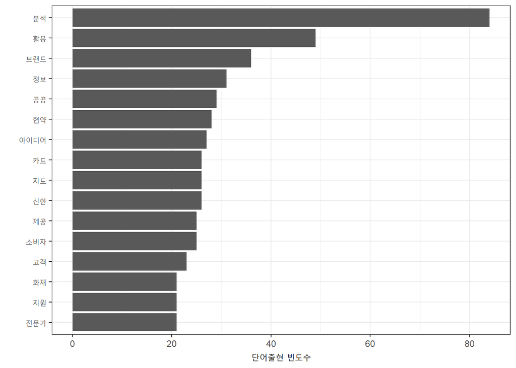

```r
ds_noun_df %>%
  count(text_no_pos, sort=TRUE)  %>%
  filter(!text_no_pos %in% c("데이터", "빅", "빅데이터")) %>%
  top_n(15) %>%
  ggplot(aes(x=fct_reorder(text_no_pos, n), y=n)) +
    geom_col() +
    theme_bw() +
    coord_flip() +
    labs(x="", y="단어출현 빈도수")
```

## 3.2 빅데이터 관련 두 언론사

빅데이터 관련 기사수가 많은 “블록체인밸리”, 그리고 “연합뉴스”를 대상으로 어떤 단어가 많이 사용되었는지 비교해보자.

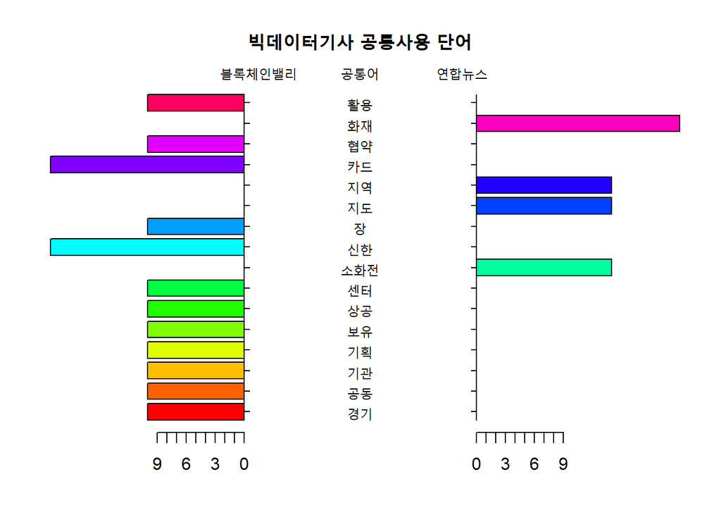

```
[1] 5.1 4.1 4.1 2.1
```

```r
top_df <- ds_noun_df %>%
  filter(source %in% c("블록체인밸리", "연합뉴스")) %>%
  count(source, text_no_pos, sort=TRUE)  %>%
  filter(!text_no_pos %in% c("데이터", "빅", "빅데이터")) %>%
  spread(source, n, fill =0) %>%
  mutate(`차이` = abs(`블록체인밸리` - `연합뉴스`)) %>%
  top_n(15, `차이`)

library(plotrix)
pyramid.plot(top_df$블록체인밸리, top_df$연합뉴스,
             labels = top_df$text_no_pos,
             gap = 12,
             top.labels = c("블록체인밸리", "공통어", "연합뉴스"),
             main = "빅데이터기사 공통사용 단어", unit = NULL)
```

[^1]: [Jinseog Kim(2018), “웹에서 텍스트 자료의 수집”,Dongguk University](http://datamining.dongguk.ac.kr/lecture_select.php?lid=201813&y=2018&s=1)
[^2]: [KoSpacing, “한글 띄어쓰기 패키지를 사용해보자”](https://mrchypark.github.io/post/kospacing-한글-띄어쓰기-패키지를-사용해보자/)
[^3]: [package install error on windows #3](https://github.com/haven-jeon/KoSpacing/issues/3)
[^4]: [한글 형태소 품사 (Part Of Speech, POS) 태그표 : 한글 형태소의 품사를 ’체언, 용언, 관형사, 부사, 감탄사, 조사, 어미, 접사, 어근, 부호, 한글 이외’와 같이 나누고 각 세부 품사를 구분한다.](http://kkma.snu.ac.kr/documents/index.jsp?doc=postag)